# Kids and the top 1%: how the numbers were built

A guide to the SCF microdata, the sample, and every estimate in `blog_post_text.md`

Author

Mike Konczal

Published

October 16, 2026

**Scope: the post and its two footnotes**

This is the methods companion to the post. It documents the stock-ownership statistic, the four figures actually embedded in the post, the income and wealth comparisons, the historical comparison, and the ranking and child-count checks in its footnotes. It also explains the microdata database well enough to reconstruct those results. Numerical tables read the saved analysis files; `graphics/post_numbers.csv` was built 2026-10-15 21:43 EDT. The separate fact check assesses the post’s external sources and distinguishes empirical findings from interpretation.

# 1 The SCF in one page

The Survey of Consumer Finances is a family-finance survey sponsored by the Federal Reserve Board and conducted by NORC. It runs every three years and is a principal source for measuring the distribution of US family wealth. The 2025 results were [released on October 9, 2026](https://www.federalreserve.gov/newsevents/pressreleases/other20261009a.htm), so the post’s “last week” is accurate as of October 16, 2026. The modern, comparable series starts in 1989, so there are 13 waves through 2025. Each wave interviews roughly 3,000 to 6,500 families about their balance sheets (assets and debts), their income, and their demographics.

Three features of its design matter for this project.

**It oversamples the rich, on purpose.** The SCF uses two samples. One is a standard area-probability sample of US households. The other is a “list sample” drawn from IRS Statistics of Income tax records, which heavily oversamples high-income and high-wealth families. People on the Forbes 400 list are excluded. Weights bring the combined sample back to the population. This is why the SCF can say something about the top 1%: a standard household survey of a few thousand families would have a few dozen of them at most.

**“Family” and “head” have specific meanings.** The unit is the *primary economic unit* (PEU): the core individual or couple who own or rent the home, plus everyone financially dependent on them. A household can contain financially independent people outside its PEU, so “family” and “household” are not interchangeable statistical universes. The Fed labels one person the “reference person,” and calls them the “head” in its publications. The 2025 codebook defines the reference person as the single core individual in a PEU without a core couple, and in a couple as “the male in a mixed-sex couple or the older individual in the case of a same-sex couple.” When this document says “head aged 45-64,” it means that person’s age.

**Timing.** Balance sheets refer to the interview date. Actual annual income refers to the *previous calendar year*: the 2025 survey asks about 2024 income. Usual income is a normal-year alternative to that actual amount, not income observed during 2025.

# 2 Where the data live

Everything is published at the Fed’s SCF page, https://www.federalreserve.gov/econres/scfindex.htm. There is no login or API key. Each wave has its own page with download links; the file names follow fixed patterns, so they can be pulled directly from `https://www.federalreserve.gov/econres/files/`. This project uses three kinds of files.

| File | What it is | Fed file name (2025 example) | Where it lives here | Used for |
| --- | --- | --- | --- | --- |
| **Summary extract** | Roughly 350 cleaned, Fed-constructed variables per family (net worth, income, `KIDS`, age, marital status, race, education…) in a consistent format across waves. Dollar values are restated in 2025 dol… | `scfp2025excel.zip` (one CSV inside, despite the name) | `data_raw/zips/`, unzipped to `data_raw/xlsx/SCFP{YEAR}.csv` | Income, net worth, age, children at home, weights, stock holdings |
| **Full public data set** | Every question as asked, about 5,000+ raw variables named `X1`, `X5910`, etc. Dollar values are nominal. | `scf2025s.zip` (Stata `.dta` inside); 1989-2001 use two-digit years (`scf89s.zip` through `scf01s.zip`); 2004 onward use four digits | `data_raw/full/p{YY}i6.dta` (1992 is `p92i4.dta`) | Children living elsewhere (`X5910`), marriage histories, household relationships and residence, partner age |
| **Replicate weights** | 999 bootstrap replicate weights for computing sampling standard errors. | `scf2025rw1s.zip` | `data_raw/rw/p{YY}_rw1.dta` (1989-1998 and 2013-2025) | Standard errors on the headline gaps |

The **codebook** for each wave documents every `X` variable: exact question wording, codes, and disclosure edits. It is a plain-text file at `https://www.federalreserve.gov/econres/files/codebk{YEAR}.txt`. Local copies for 2013, 2019, 2022 and 2025 are in `docs/`; these re-downloadable files are excluded from Git. For a fresh checkout, create `docs/` and download the desired codebooks from the Fed before looking up variables. To look up a variable, search the codebook for its name at the start of a line, for example `grep -n "^X5910" docs/codebk2025.txt`.

The folder name `xlsx/` is historical: these inputs are CSV files, not Excel workbooks. An `.rds` file is a serialized R object, not a database server or an SQL database. Here it stores a `data.table` that can be read with `readRDS()`.

The full-data files are large (about 0.2-0.3 GB each as `.dta`, 2.9 GB for all 13 waves). `R/01_download.R` fetches only the summary extracts. The full-data and replicate-weight files were downloaded by hand. To fetch them from scratch (run from the project root):

```bash
# Full public data, all 13 waves (1989-1998 use two-digit years in the file name)
mkdir -p data_raw/full data_raw/rw output
for y in 89 92 95 98 01; do curl -fsL -o data_raw/full/scf${y}s.zip https://www.federalreserve.gov/econres/files/scf${y}s.zip; done
for y in 2004 2007 2010 2013 2016 2019 2022 2025; do curl -fsL -o data_raw/full/scf${y}s.zip https://www.federalreserve.gov/econres/files/scf${y}s.zip; done
# Replicate weights: the five pooled waves used in the significance tests, plus 1989-1998 for the period test (R/27)
for y in 2013 2016 2019 2022 2025; do curl -fsL -o data_raw/rw/scf${y}rw1s.zip https://www.federalreserve.gov/econres/files/scf${y}rw1s.zip; done
for y in 89 92 95 98; do curl -fsL -o data_raw/rw/scf${y}rw1s.zip https://www.federalreserve.gov/econres/files/scf${y}rw1s.zip; done
# Unzip in place
for f in data_raw/full/*.zip; do unzip -o "$f" -d data_raw/full; done
for f in data_raw/rw/*.zip; do unzip -o "$f" -d data_raw/rw; done
```

# 3 Five things that trip up new SCF users

## 3.1 Every family appears five times (multiple imputation)

When respondents skip a question or answer with a range, the Fed fills in the missing value by statistical imputation. Rather than release one guess, it releases **five complete copies of the data set** (“implicates”), each with a different random draw for the imputed values. So a file with 4,360 families has 21,800 rows.

Two ID variables tie this together: `YY1` is the family’s case number and `Y1` = 10 × `YY1` + implicate number (1 to 5). Here is one 2025 family across its five implicates. Net worth and income differ in this example. Some demographic values can also differ across implicates; identical values do not by themselves establish that an answer was observed rather than imputed.

```r
sx <- readRDS("data/scf_linked.rds")
ex <- sx[year == 2025, if (uniqueN(NETWORTH) == 5 && uniqueN(INCOME) > 1) .SD, by = YY1][YY1 == min(YY1)]
ex[, .(year, YY1, Y1, implicate, AGE, KIDS, NETWORTH = round(NETWORTH), INCOME = round(INCOME), WGT = round(WGT))]
```

```
    year   YY1    Y1 implicate   AGE  KIDS NETWORTH INCOME   WGT
   <num> <int> <int>     <int> <int> <int>    <num>  <num> <num>
1:  2025     2    21         1    69     1  3005160  66757 13728
2:  2025     2    22         2    69     1  2988260  65730 14391
3:  2025     2    23         3    69     1  2984260  66757 13047
4:  2025     2    24         4    69     1  2992170  65730 14897
5:  2025     2    25         5    69     1  3016280  67784 16109
```

The released weight can also differ slightly across implicates. That is another reason to always carry `WGT` row by row rather than attaching one weight per family.

The database stacks all five implicates and preserves each row’s weight. Some descriptive calculations take a weighted mean on that pooled file; the headline inference and principal chart points average the five implicate-level estimates. These differ slightly when subgroup membership or weights vary. The largest audited difference among recent income-bin 3+ shares is below 0.01 percentage point. The spread across implicates enters the imputation component of the standard errors, as explained below.

## 3.2 Weights are essential, and the extract’s weight is pre-divided by 5

Because of the oversample, unweighted SCF statistics are meaningless for population questions. In the summary extract the weight `WGT` is already divided by 5, so summing it over all rows of a wave (all five implicates) gives the number of US families. The full data set’s weight, `X42001`, is *not* divided by 5. This project always uses `WGT` from the extract.

```r
sx[, .(sample_families = uniqueN(YY1), rows = .N, us_families_millions = round(sum(WGT) / 1e6, 1)), by = year][order(year)]
```

```
Key: <year>
     year sample_families  rows us_families_millions
    <num>           <int> <int>                <num>
 1:  1989            3143 15715                 93.0
 2:  1992            3906 19530                 95.9
 3:  1995            4299 21495                 99.0
 4:  1998            4305 21525                102.5
 5:  2001            4442 22210                106.5
 6:  2004            4519 22595                112.1
 7:  2007            4417 22085                116.1
 8:  2010            6482 32410                117.6
 9:  2013            6015 30075                122.5
10:  2016            6248 31240                126.0
11:  2019            5777 28885                128.6
12:  2022            4595 22975                131.3
13:  2025            4360 21800                135.0
```

The oversample is visible in our own analysis sample. Pooling 2013-2025, families in the top 1% of income (for their age) are **1390** of the **11,215** families in the sample, or 12% of the unweighted cases, though their weighted share is approximately 1% within each age-band ranking. That is what makes a top-1% estimate possible at all.

## 3.3 Dollar units differ between the two data sets

The summary extract restates every wave in the dollars of the newest survey (2025 dollars, deflated by the Fed with CPI-U-RS). The full public data are in nominal dollars. In this project **all dollar amounts used in comparisons come from the extract** (`INCOME`, `NORMINC`, `NETWORTH`, `EQUITY`). The post’s child-count and marriage checks take only counts, codes and ages from the full data. They do not join nominal raw dollars to real extract dollars. Annual income is a flow; net worth is assets minus debts, a stock. Neither is equivalized for family size.

## 3.4 Unasked questions are often coded 0, not missing

Many codebook entries use `0` for “Inap.” (inapplicable: the question was skipped for this family) and negative codes for special answers. `X5910` codes “None” as `-1`. Always read the codebook entry before using a raw variable. `R/07_kids_income.R` converts `X5910` with `pmax(x5910, 0)` so that “None” becomes 0.

```r
# Raw coding of X5910 in the 2025 full public file, before any recoding (implicate 1 only)
f25 <- as.data.table(zap_labels(read_dta("data_raw/full/p25i6.dta", col_select = c(y1, x5910))))
f25[y1 %% 10 == 1, .N, by = .(x5910)][order(x5910)]
```

```
    x5910     N
    <num> <int>
 1:    -1  1948
 2:     1   571
 3:     2   864
 4:     3   502
 5:     4   240
 6:     5   114
 7:     6    58
 8:     7    31
 9:     8    13
10:     9    10
11:    10     9
```

## 3.5 The public file is not the Fed’s internal file

To protect respondents, the public data are altered before release: some values are top-coded (`X5910` at 10), rounded, or perturbed, and some variables are withheld. Published Fed tables use the internal data, so public-file estimates can differ slightly, especially means of skewed variables at the very top.

# 4 How the microdata database works

## 4.1 Three files, three different jobs

The summary extract supplies the harmonized financial and demographic variables. The full public file supplies the detailed family questions that the extract omits. Replicate weights supply alternative sample weights for uncertainty calculations; they do not add families or observations of births.

The linkage is **survey year × family × implicate**. `YY1` identifies a family only within a survey year. `Y1` identifies its particular imputed record within that year. The first implicate of family 1001, for example, has `Y1 = 10011`; the fifth has `Y1 = 10015`. These are illustrative identifiers. `R/02_build_db.R` renames the 1989 identifiers `X1`/`XX1` to `Y1`/`YY1`, and derives `implicate = Y1 - 10 * YY1`.

| Object | One row represents | Correct key | What it contains |
| --- | --- | --- | --- |
| `data_raw/xlsx/SCFP{YEAR}.csv` | A family in one implicate of one wave | `Y1` within the file | Fed summary variables, including `WGT`, `KIDS`, `AGE`, `NORMINC`, `INCOME`, `NETWORTH`, `EQUITY` |
| `data_raw/full/p{YY}i6.dta` (1992: `i4`) | The same family-implicate record | `y1` or 1989 `X1`, within the wave | Raw question responses, including `X5910` |
| `data/scf_linked.rds` | A summary-extract record with year attached | `(year, Y1)`, equivalently `(year, YY1, implicate)` | The 13 extracts stacked on a common schema |
| `output/kids_main.rds` | An eligible family-implicate record | `(year, Y1)` | Ages 45-64, joined child count, ranks, bins and normalized weights |
| `data_raw/rw/p{YY}_rw1.dta` | A family in implicate 1 | `y1` or 1989 `X1`, within the wave | 999 weight/multiplicity pairs |

Joining on `YY1` alone would match each of five summary rows to five raw rows and create 25 rows per family. Joining on `Y1` without year would mix unrelated families across waves. The production merge uses `(year, Y1)` and retains the summary extract’s weight. The independent raw-data audit additionally checks key uniqueness, identical ID sets, and the row-by-row relationship `5 * WGT = X42001` up to numerical precision.

## 4.2 Stacking is harmonization, not following families over time

`R/02_build_db.R` reads all 13 CSVs, normalizes the identifier names and column types, drops the nonnumeric `WILSH` placeholder, and fills absent columns with `NA` when stacking. It checks implicates 1-5, equal row counts across implicates within each full wave, and no duplicate `Y1` within a wave. The resulting file has **312,540 rows and 363 columns**. It is a repeated cross-section. A matching case number in 2019 and 2022 does not identify the same family.

The substantive harmonization is explicit: usual-income categories are blanked where the usual-income amount was not collected (1989 and 1992), rather than treating populated category codes as comparable data. Financial variables keep the Fed’s released 2025-dollar conversion. The code does not re-deflate them.

`R/07_kids_income.R` reads selected columns from each full public file, normalizes raw names to lower case, adds year, and merges them onto the extract. It stops if the joined row count differs from the extract. It then constructs `kids`, applies the age restriction, computes ranks within each year/implicate/age band, and saves the analysis file. Selecting a few columns avoids loading every raw question into memory.

The age restriction is applied to each implicate’s `AGE`. If an imputed age crosses a sample boundary, a family need not have all five records in the restricted sample. This is why five times a count of unique families need not equal its analysis-row count. Reported family counts use `uniqueN(case)`, with `case = paste(year, YY1)`, and count a family if it is eligible in any implicate.

## 4.3 The path from raw responses to the post

```
Fed summary CSVs -> R/02 -> data/scf_linked.rds
                                   + full public responses -> R/07 -> output/kids_main.rds
                     + replicate weights -> R/25 -> headline contrasts   |
                                           R/26 -> ranking checks       |
                                           R/27 -> period changes       |
                                           R/28 -> bin intervals        |
                     + raw roster/marital items -> R/29 -> counting checks
                                           R/22 -> figures and post_numbers.csv
```

`R/01_download.R` records the summary archive URL, MD5, size, file modification time and manifest-recording time in `data_raw/download_manifest.csv`. Modification and recording times are not proof of a fresh download: existing archives are reused unless `--force` is requested, which selects a datestamped raw-data directory. Other input hashes and independently checked source provenance are retained under `audit/`. Raw archives, codebooks and derived RDS files are excluded from Git, so a clone requires the downloads and rebuild steps below.

# 5 Definitions

## 5.1 Children

$$\text{kids} \;=\; \underbrace{\texttt{KIDS}}_{\text{roster children}} \;+\; \underbrace{\max(\texttt{X5910},\,0)}_{\text{children living elsewhere}}$$

- `KIDS` (summary extract): the number of household-roster members coded as a child of the reference person or spouse/partner. The Fed construction counts relationship codes 4, 13 and 36. In the recent public file, code 4 is labeled “CHILD (in-law)”; thus `KIDS` can include resident children-in-law. The independent audit reconstructs `KIDS` from all ten roster positions, with zero disagreements across the 13 waves. The roster also lists financially dependent children who do not usually live there (for example, college students), and they are counted too.
- `X5910` (full data, asked in every wave since 1989): *“Altogether, including children from previous marriages and adopted children, how many sons and daughters do you (or your spouse/partner) have who do not live with you?”* Interviewers are told to include only living children and stepchildren. It is top-coded at 10 in the recent public files; three families in the 1989 and 1992 files report more (up to 16), which cannot change the 3+ share and barely moves the early-period means.

The SCF never asks “how many children have you ever had.” The sum above is the closest available measure. It counts adopted children and stepchildren, it counts children-in-law at home, and it misses children who have died. It is a count of children associated with the current family, not of births to one person.

**Possible double count.** A dependent child who is on the roster but away from home (relationship codes 4, 13 or 36, with residence code 5, “does not usually live here”) can be reported again in `X5910` as a child who does not live with the respondent. Having both kinds of entries establishes possible overlap, not which children overlap. `R/29_family_count_checks.R` subtracts the maximum possible overlap, the smaller of those two counts, either from both groups or only from the top 1%. Both rankings retain positive, statistically significant gaps under these specified overlap corrections; the full table is in the counting-checks section below. These scenarios address possible duplication captured by the residence flags, not all child-count measurement error.

## 5.2 Sample: families with a head aged 45 to 64

Restricting to heads aged 45-64 reduces the problem of observing families before childbearing is complete, while `X5910` recovers living children who have left the household. It cannot establish that childbearing is complete for either partner. The count is still a family child count, not completed fertility (see above). The age is the reference person’s, which in a mixed-sex couple is the man’s, so a younger partner may still have children. The older-family check in `R/29_family_count_checks.R`, restricting to heads aged 50-64 with a partner aged at least 45 when present, also finds significant income and wealth gaps. The trade-off is that income and wealth are measured *after* the children arrive (see Interpretation below).

## 5.3 Income and wealth ranks

- **Income measure.** `NORMINC`, the family’s “usual” income: respondents are asked whether last year’s income was unusually high or low, and if so, what it would have been in a normal year. Using it is intended to reduce rank changes caused by unusually high or low annual income; it does not eliminate transitory measurement error. The usual-income dollar amount behind `NORMINC` was not collected in 1989 and 1992 (1992 asks only whether income was unusually high or low, `X7650`), so those waves use actual `INCOME`. These are broad family-income measures, including wages, business income, interest, dividends, capital gains, rents and some transfers.
- **Ranking within age band.** Each family gets a weighted percentile rank (the midpoint of its cumulative weight) among families **in the same survey year, implicate, and 5-year age band of the head** (45-49, 50-54, 55-59, 60-64). This compares families at the same stage of life: a 62-year-old near retirement is ranked against other 60-64-year-olds, not against 50-year-olds at peak earnings. Net worth (`NETWORTH`) is ranked the same way.
- **Bins and ties.** Twelve displayed bins: nine lower deciles and the top decile split into 90th-95th, 95th-99th and top 1%. Midpoint ranks assign whole records to bins, so weighted bin sizes are approximate. Equal financial values can be split by their deterministic record order rather than receiving a common tied rank. Replicate calculations sort by year and `Y1` before re-ranking.
- **Dollar labels on the charts.** The x-axis labels show the income at each percentile cutoff among all heads 45-64 (pooled 2013-2025, 2025 dollars). Because the ranks are within age band and survey year, these are approximate: 58-87% of each bin’s families fall inside its labeled range, best at the top. The top-1% cutoff is about **$1.4 million** of usual income; the median top-1% family has about **$2.1 million**.

## 5.4 Pooling waves

The 2025 wave has only 208 top-1% families in this age range, too few for stable estimates. The main estimates pool the five most recent surveys, **2013, 2016, 2019, 2022 and 2025**. The post’s historical chart compares 1989-1998 (four surveys) with 2013-2025 (five surveys). The database also retains 2001-2010, which is not displayed in the post.

Within a period each **wave gets equal total weight** (`w = WGT / sum(WGT)` within each year and implicate). Without this, later waves would count for more simply because the population grew.

# 6 Estimation and standard errors

## 6.1 What is averaged, and over which denominator?

The post reports weighted family shares, not the share of children living in each income group. For each wave $t$, implicate $m$ and family record $i$, define $a_{itm}=\mathrm{WGT}_{itm}/\sum_{i\in S_{tm}}\mathrm{WGT}_{itm}$, where $S_{tm}$ is the age-eligible sample. This gives each wave equal weight before pooling. For group $G$, the pooled-period share within an implicate is

$$\hat p_{Gm}=100\frac{\sum_t\sum_{i\in S_{tm}}a_{itm}\,1\{i\in G\}\,1\{\mathrm{kids}_{itm}\ge3\}}{\sum_t\sum_{i\in S_{tm}}a_{itm}\,1\{i\in G\}}.$$

Replace the final indicator in the numerator with `kids` for a mean, and omit the factor 100. Each wave has equal weight in the underlying sample; pooled group shares are ratios of summed moments, not an unweighted average of wave-specific group shares. Small differences in realized group mass can give different contributions to the subgroup denominator. In restricted-family checks, weights retain their full eligible-sample normalization and the numerator and denominator select the stated subgroup.

**The inference outputs average the five implicate-specific ratios:** $\hat p_G=\frac15\sum_m\hat p_{Gm}$. The principal chart points in `R/22` are also averages of implicate-specific bin estimates; `R/28` verifies that their points agree with its estimates. Some descriptive calculations, including the historical chart and the initial `R/07` tables, instead pool all five sets of weighted records and take one ratio. These conventions are very close here, but are not algebraically identical when subgroup denominators vary across implicates. The existing income-bin audit finds a largest discrepancy below 0.01 percentage point. This distinction is documented rather than silently changing an estimator. In particular, a comment in `R/scf_functions.R` saying pooled means are identical to the mean of implicate means is too strong for subgroup means.

## 6.2 Sampling error and imputation error are different

The [Fed’s standard-error documentation](https://www.federalreserve.gov/econres/files/Standard_Error_Documentation.pdf) requires accounting for both. The five implicates express uncertainty about missing responses; they are not five independent surveys. The 999 supplied bootstrap replicates express uncertainty from the complex sample design.

`R/25_rep_inference.R` uses the first implicate for sampling variance. In each wave and replicate $r$, the effective weight is `wt1b{r} * mm{r}`; missing products are set to zero. Raw replicate IDs are matched to the first-implicate `Y1` IDs, including the 1989 `X1` naming exception where applicable. Within each replicate, weights are normalized again and financial ranks are recomputed within age band before group membership is assigned.

For a single-wave statistic, sampling variance is the sample variance of 999 replicate estimates, with denominator 998. For the pooled statistics, `R/25` applies a delta-method gradient to each wave’s replicate numerator/denominator moments, then sums variance contributions across waves, treating the surveys as independent cross-sections. This preserves the covariance between the top group and its comparison group. It is why subtracting two separately computed standard errors, or inspecting overlapping chart bands, is not a test of their difference.

If $B=\frac14\sum_{m=1}^5(\hat\theta_m-\bar\theta)^2$ is the between-implicate variance of the **contrast itself**, the reported standard error is

$$\operatorname{SE}(\hat\theta)=\sqrt{V_s+(1+1/5)B}.$$

Intervals use $\hat\theta\pm1.96\operatorname{SE}$; p-values are two-sided normal approximations. “Statistically significant” in the post means a pointwise 95% interval excludes zero. These intervals are not adjusted for the many outcomes and sensitivity definitions examined.

`R/28_bin_intervals.R` uses the same procedure for each charted bin. `R/27_period_change_test.R` adds independent sampling variance across the two periods and computes imputation variance on the recent-minus-early contrast. `R/26_top1_definitions.R` redefines the ranking population as stated in each row. Its ranking pooled across years depends jointly on all waves: production uses joint replicate moment draws, and the independent audit additionally perturbs each wave separately and re-estimates the common ranks.

The exploratory regressions in `R/07` and single-wave calculations with fixed ranks are not the source of the post’s headline significance claims. Those claims use `R/25` through `R/29`.

# 7 Every chart and number in the post

## 7.1 Stock ownership in the introduction (2025)

All families in 2025 (not just ages 45-64), sorted by net worth. `EQUITY` from the extract is stock held directly *and* indirectly through mutual funds and retirement accounts. The bottom 50% by wealth own **1.1%** of stock (SE 0.1); the wealthiest 10% own **81%**. This is a share of families’ direct and indirect stock holdings, not a share of all corporate equity outstanding. The ranking population is all ages; the fertility comparisons below use ages 45-64.

## 7.2 Income figure and the exactly-three comparison, 2013-2025

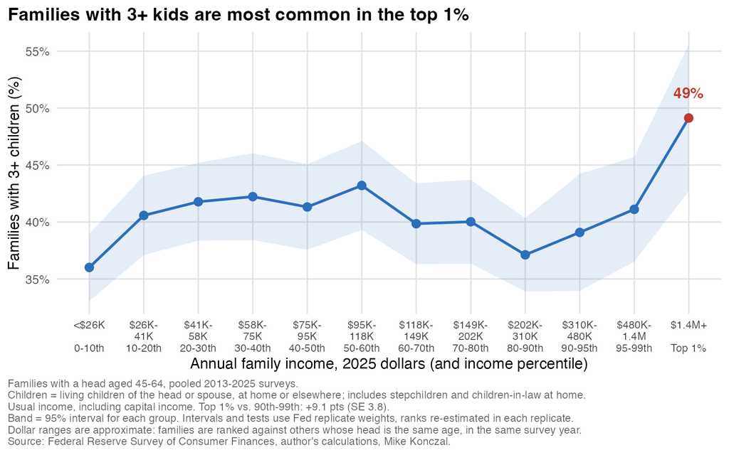

| Income group | 3+ children | SE | Average children | SE |
| --- | --- | --- | --- | --- |
| Bottom 10% | 36% | 1.5 | 2.23 | 0.06 |
| 40th-50th | 41% | 1.9 | 2.43 | 0.08 |
| 50th-60th | 43% | 2 | 2.49 | 0.08 |
| 80th-90th | 37% | 1.6 | 2.33 | 0.05 |
| 90th-95th | 39% | 2.6 | 2.29 | 0.07 |
| 95th-99th | 41% | 2.3 | 2.43 | 0.06 |
| **Top 1%** | **49%** | 3.3 | **2.51** | 0.08 |

Standard errors in the table are replicate-weight SEs for each bin (`R/28_bin_intervals.R`; percentage points and children), the same ones that draw the chart bands. The formal tests use replicate weights on the pooled 2013-2025 sample (`R/25_rep_inference.R`):

- Top 1% vs. 90th-99th, share with 3+ children: **+9.1 (SE 3.8; 95% CI 1.8 to 16.5) points**; the 95% interval excludes zero.
- Where the gap sits: 34% of the top 1% have exactly three children, against 24% of the 90th-99th (gap +9.9 (SE 3.5; 95% CI 3.1 to 16.7) points). Four or more: 15% vs. 16% (gap -0.8 (SE 2.6; 95% CI -5.8 to 4.3)). The excess is concentrated in the exactly-three category; this does not measure a transition to a third birth.
- Average children, top 1% vs. 90th-99th: +0.16 (SE 0.10; 95% CI -0.03 to 0.34); the 95% interval includes zero. The estimated average is higher, but the interval includes zero, as the post states.

## 7.3 Historical figure: 1989-1998 versus 2013-2025

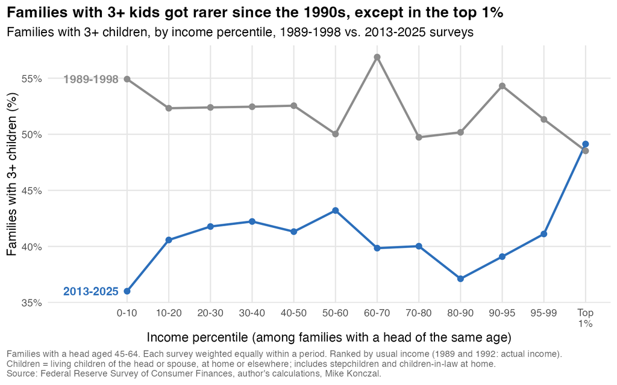

The figure compares age-eligible repeated cross-sections, with the same within-year, within-implicate, five-year-age-band ranks. It is not a panel following the same families or a time series of births. The overall share with 3+ children declines from 52.4% to 40.3%.

`R/27_period_change_test.R` directly tests the change, rather than inferring it from one period being significant and another not. The table shows levels in percent and changes in percentage points, with 95% intervals. Because usual-income amounts were not collected in 1989 and 1992, the production-income series mixes actual and usual income in its early period. The all-actual-income sensitivity preserves an income definition across periods; net worth supplies another check.

```r
pc <- readRDS("output/kids_period_change.rds")
pf <- function(z) sprintf("%+.1f (%.1f to %.1f)", z$est, z$lower, z$upper)
lv <- function(z) sprintf("%.1f", z$est)
pt <- rbindlist(lapply(unique(pc$rank), function(r) { z <- pc[rank == r]; g <- function(pp, st) z[period == pp & stat == st]
  data.table(Ranking = r, `Top 1%, 1989-98` = lv(g("early", "top")), `Top 1%, 2013-25` = lv(g("recent", "top")),
             `Change, top 1%` = pf(g("change", "top")), `Change, 90th-99th` = pf(g("change", "aff")),
             `Change in gap` = pf(g("change", "gap")), `p (gap)` = sprintf("%.3f", g("change", "gap")$p)) }))
knitr::kable(pt)
```

| Ranking | Top 1%, 1989-98 | Top 1%, 2013-25 | Change, top 1% | Change, 90th-99th | Change in gap | p (gap) |
| --- | --- | --- | --- | --- | --- | --- |
| income (production) | 48.5 | 49.1 | +0.6 (-9.7 to 10.9) | -13.0 (-18.6 to -7.5) | +13.6 (2.1 to 25.2) | 0.021 |
| actual income | 52.1 | 49.7 | -2.4 (-11.9 to 7.1) | -14.4 (-20.5 to -8.4) | +12.1 (0.5 to 23.6) | 0.040 |
| net worth | 51.1 | 50.2 | -0.9 (-10.0 to 8.2) | -13.1 (-18.7 to -7.4) | +12.1 (1.4 to 22.9) | 0.027 |

Under all three rankings the gap widened significantly. The 90th-99th share fell roughly 13-14 points; the top 1% share shows no detectable change, though its interval is wide (roughly plus or minus 10 points). Intervals are pointwise.

## 7.4 The two wealth figures

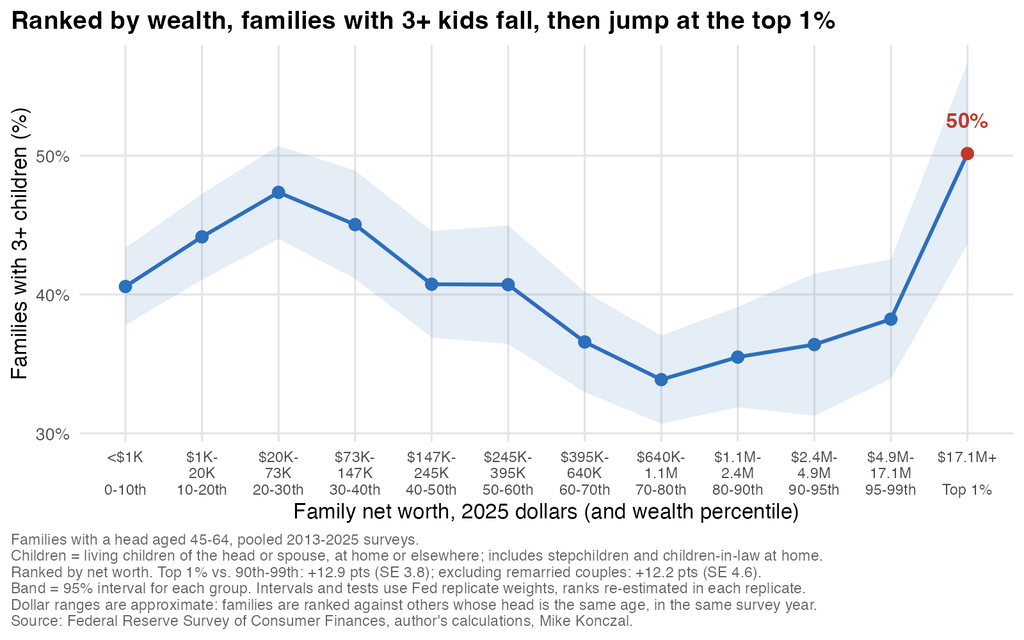

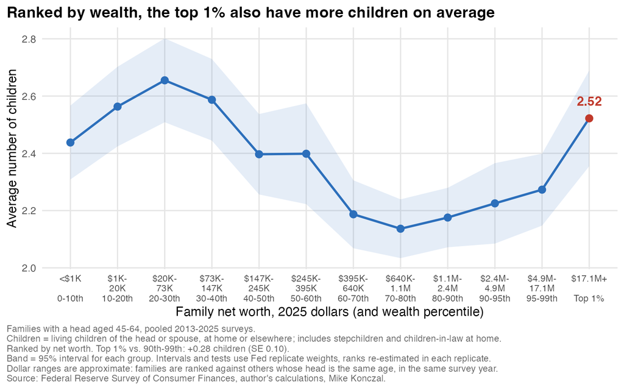

The sample, family child count and inference are the same as for income; families are instead ranked by net worth within year, implicate and age band. The top-1% wealth cutoff is about **$17.1 million**. The share with 3+ children peaks at 47% in the 20th-30th percentile (about $20,000 to $73,000), falls to 34% in the 70th-80th (about $640,000 to $1.1 million), then is 50% at the top 1%. Average children follow the same shape: 2.66, 2.14, and 2.52.

Replicate-weight tests on the pooled 2013-2025 sample, top 1% vs. 90th-99th by wealth: +12.9 (SE 3.8; 95% CI 5.5 to 20.4) points for the share with 3+ children (the 95% interval excludes zero), and +0.28 (SE 0.10; 95% CI 0.08 to 0.47) for average children. The top-1% and 90th-99th means are 2.52 and 2.25. Four-or-more-child shares are 19.0% and 13.8%; their difference is +5.2 (SE 2.5; 95% CI 0.4 to 10.0) points.

## 7.5 Robustness: how the top 1% is defined

`R/26_top1_definitions.R` reruns the headline test (share with 3+ children, top group minus the rest of the top 10%) under different definitions of the top group. The outcome, sample (heads 45-64, 2013-2025) and inference are unchanged: 999 replicate weights per wave with ranks re-estimated in every replicate, plus imputation variance, as in `R/25`. For the pooled-across-years ranking, ranks depend on all five waves at once, so the variance is taken over replicate draws of the summed moments rather than summed wave by wave. The script checks that its baseline row reproduces `R/25` exactly and also writes a standalone table, `definitions.html`.

```r
td <- readRDS("output/kids_top1_defs.rds")
fmt <- function(z) if (!nrow(z)) "n/a" else sprintf("%+.1f (%.1f to %.1f)%s", z$gap, z$lower, z$upper, if (z$lower > 0) "" else ", n.s.")
tab <- unique(td[, .(id, label)])
tab[, `Income gap, pts (95% CI)` := vapply(id, function(i) fmt(td[id == i & rank == "income"]), "")]
tab[, `Wealth gap, pts (95% CI)` := vapply(id, function(i) fmt(td[id == i & rank == "wealth"]), "")]
knitr::kable(tab[, -"id"], col.names = c("Definition", names(tab)[3:4]))
```

| Definition | Income gap, pts (95% CI) | Wealth gap, pts (95% CI) |
| --- | --- | --- |
| Current definition | +9.1 (1.8 to 16.5) | +12.9 (5.5 to 20.4) |
| Wider age bands | +12.0 (4.5 to 19.5) | +13.4 (7.0 to 19.8) |
| One ranking for all 45-64 | +11.5 (4.4 to 18.6) | +16.1 (9.4 to 22.9) |
| Whole population | +8.8 (2.5 to 15.0) | +10.8 (4.4 to 17.1) |
| Pooled across 2013-2025 | +13.8 (6.5 to 21.0) | +14.2 (7.1 to 21.3) |
| Actual income | +10.6 (3.1 to 18.1) | n/a |
| Top 2% | +7.4 (1.4 to 13.5) | +9.3 (2.6 to 16.0) |
| Top 0.5% | +14.6 (6.3 to 23.0) | +12.5 (5.2 to 19.8) |

15 of 15 gaps have 95% intervals that exclude zero. The definitions select heavily overlapping families from the same surveys, so these are checks that the choice of definition is not driving the result, not independent confirmations. Intervals are pointwise and unadjusted for multiple comparisons.

## 7.6 Counting checks (footnote 2 of the post)

`R/29_family_count_checks.R` reruns the headline test (top 1% vs. 90th-99th, share with 3+ children) under the counting and family-history checks cited in the post’s second footnote. Ranks come from the full age-eligible sample before the extra restriction, and are re-estimated from that sample in every replicate. Thus these checks change which families or children enter the comparison, without redefining wealth or income ranks inside the restricted subgroup. The overlap corrections subtract the largest possible double count, `min(A, B)`, where A is roster children who do not usually live in the household (relationship codes 4, 13 or 36 with residence code 5) and B is `X5910`. “Currently married, first marriage” requires both partners to be currently married to each other (`X8023` = 1, `X105` = 1) and both to report a first marriage, so unlike `R/24`’s flag it excludes cohabiters. The older-family check keeps heads aged 50-64 whose spouse or partner, if present, is at least 45 (`X19`). The script checks that its baseline reproduces `R/25` and that the separate checks reproduce the independent audit (`audit/review_20261015/results/independent_inference.csv`).

```r
cc <- readRDS("output/kids_count_checks.rds")
lab <- c(baseline = "Baseline", overlap_all = "Subtract maximum possible double count, all families",
         overlap_top = "Subtract it only in the top 1% (adverse case)", strict_first = "Currently married, both in a first marriage",
         older = "Head 50-64, partner (if any) 45+", strict_first_overlap_all = "First marriage + double-count correction, all families",
         strict_first_overlap_top = "First marriage + correction only in the top 1%")
cf <- function(z) sprintf("%+.1f (%.1f to %.1f)", z$gap, z$lower, z$upper)
ct <- data.table(Check = lab[unique(cc$spec)],
                 `Income gap, pts (95% CI)` = sapply(unique(cc$spec), function(s) cf(cc[rank == "inc_rank" & spec == s])),
                 `Wealth gap, pts (95% CI)` = sapply(unique(cc$spec), function(s) cf(cc[rank == "nw_rank" & spec == s])))
knitr::kable(ct)
```

| Check | Income gap, pts (95% CI) | Wealth gap, pts (95% CI) |
| --- | --- | --- |
| Baseline | +9.1 (1.8 to 16.5) | +12.9 (5.5 to 20.4) |
| Subtract maximum possible double count, all families | +8.5 (1.0 to 15.9) | +13.2 (5.5 to 20.8) |
| Subtract it only in the top 1% (adverse case) | +7.8 (0.4 to 15.2) | +12.3 (4.6 to 19.9) |
| Currently married, both in a first marriage | +13.2 (3.9 to 22.6) | +11.0 (1.6 to 20.4) |
| Head 50-64, partner (if any) 45+ | +12.0 (3.9 to 20.2) | +15.2 (7.7 to 22.7) |
| First marriage + double-count correction, all families | +11.8 (2.4 to 21.3) | +10.6 (0.9 to 20.4) |
| First marriage + correction only in the top 1% | +11.4 (2.0 to 20.9) | +9.9 (0.3 to 19.6) |

All intervals exclude zero; the adverse combined wealth check only narrowly (lower bound 0.3). These checks address specific counting problems. They cannot identify births to one person or rule out every kind of blended family, for example children from earlier non-marital relationships.

# 8 Interpretation and limits

The outcome is an imperfect current-family child count. It includes adopted children, stepchildren and resident children-in-law, excludes deceased children, and can overlap across roster and elsewhere responses. It does not recover births to a particular woman or the probability that a two-child parent subsequently has a third birth. “Exactly three” describes the composition of the cross-section, not a birth transition.

The strict current-first-marriage and overlap checks support the particular robustness claims in footnote 2. They cannot rule out children from earlier non-marital relationships, misclassification of resident adult children, or every form of differential reporting. Broader measurement sensitivities are retained in the audit documentation, including results whose intervals include zero. Those sensitivities change the measure or population and do not justify a claim that every conceivable correction preserves significance.

The estimates associate child counts with income and wealth measured at ages 45-64. Childbearing can itself affect later earnings and wealth, and family formation, preferences, inheritance and other omitted factors can affect both. There is no design here identifying the causal effect of money, childcare prices, or a policy on births. Nor does the survey measure whether a third child is a status symbol. The post’s proposed mechanism and policy argument are interpretations, not estimated effects.

The top-1% income share changes little between the early and recent periods, but its change interval is wide. Failure to detect a change does not establish an unchanged population share or show that rich families were insulated from every childbearing pressure. Income and wealth rankings also select different families. Their results are related checks on the same surveys, not independent replications.

Dollar labels describe pooled financial cutoffs in 2025 dollars and are approximate because the actual bins are age- and year-specific. Counts of sample families are unweighted case counts; percentages and means use survey weights. The chart bands are pointwise bin intervals; the reported gaps are tested directly. Public-data disclosure edits and the omission of the Forbes 400 limit interpretation at the extreme top.

# 9 Reproducing everything

Run from the project root. The first two steps only need rerunning if the raw data change.

```bash
mkdir -p data_raw/full data_raw/rw output   # before the hand downloads (section 2) and R/07
Rscript R/01_download.R            # summary extracts -> data_raw/xlsx/, writes data_raw/download_manifest.csv
Rscript R/02_build_db.R            # -> data/scf_linked.rds
Rscript R/07_kids_income.R         # -> output/kids_main.rds (needs data_raw/full/*.dta)
Rscript R/25_rep_inference.R       # -> output/kids_rep5.rds (needs data_raw/rw/*.dta, 2013-2025)
Rscript R/26_top1_definitions.R    # -> output/kids_top1_defs.rds, definitions.html
Rscript R/27_period_change_test.R  # -> output/kids_period_change.rds (needs data_raw/rw/*.dta, 1989-1998 too)
Rscript R/28_bin_intervals.R       # -> output/kids_bin_ci.rds (chart bands)
Rscript R/29_family_count_checks.R # -> output/kids_count_checks.rds (needs data_raw/full/*.dta)
Rscript R/22_post_kids_graphics.R  # -> graphics/*.png, graphics/post_numbers.csv
quarto render kids_methods.qmd     # this document
```

Order matters: 02 before 07; 25 and 28 before 22; 26, 27 and 29 after 25 (they check their baselines against it); and all required outputs before rendering. The broader graphics script also writes supplementary figures and exploratory numbers absent from the post. They are not additional evidence claimed by this companion. Work-hours and the older remarriage-proxy scripts are not dependencies of this document. Checks that a run worked: 02 prints families per wave (about 4,360 sample families and 135 million US families in 2025); 07 prints the main sample size (25,576 families across 13 waves); 22 ends by reporting that it wrote 337 numbers to `graphics/post_numbers.csv`.

R packages: `data.table`, `haven`, `fixest`, `ggplot2`, `scales`, `ragg`, `dplyr` (for `all_of` when selecting columns from `.dta` files).

## 9.1 File map

| Path | Role |
| --- | --- |
| `blog_post_text.md` | The post |
| `kids_methods.qmd` | This document |
| `R/scf_functions.R` | Weighted quantile and mean helpers |
| `R/rep_se.R` | Replicate-weight standard errors |
| `R/01_download.R`, `R/02_build_db.R` | Summary-extract download and stacking |
| `R/07_kids_income.R` | Merge with full data; children count; sample; ranks |
| `R/22_post_kids_graphics.R` | All charts and `post_numbers.csv` |
| `R/25_rep_inference.R` | Significance tests: replicate weights, pooled 2013-2025, ranks re-estimated |
| `R/26_top1_definitions.R`, `definitions.html` | Robustness of the headline test to the definition of the top 1% |
| `R/27_period_change_test.R` | Design-based test of the 1989-1998 vs. 2013-2025 change |
| `R/28_bin_intervals.R` | Replicate-weight 95% intervals for each bin (chart bands) |
| `R/29_family_count_checks.R` | Double-count and marriage-history checks (post footnote 2) |
| `data_raw/` | Raw Fed files (zips kept as the record of what was downloaded) |
| `docs/codebk*.txt` | Fed codebooks |

## 9.2 Verification trail and external context

The dated audit files preserve separate implementations of the estimators, rather than merely reprinting production tables. `audit/review_20261015/independent_checks.R` reconstructs counts, weights and ranks from the raw CSV and Stata files and checks them against production. The band audit independently checks all 48 bin estimates and standard errors. The revision audit checks alternative ranks, historical changes, and an independent-wave variance calculation for ranks pooled across years. See audit/README.md for commands and the distinction between primary claims and supplementary sensitivities.

The post’s economic framing comes from [Doepke et al. (2022), author-hosted working paper](https://tertilt.vwl.uni-mannheim.de/research/HandbookFertility_WP_NBER.pdf), and [Bar et al. (2018)](https://s3.amazonaws.com/real.stlouisfed.org/wp/2018/2018-022.pdf). These papers motivate the exercise; this SCF count is not a replication of their fertility measures. The specific literature attributions, Haspel article, and New York Times quotation are assessed in factcheck.html.